# DT 607—Fall 2019—Project 4—Spam/Ham Classification

Team ADM - Avraham Adler, Donny Lofland, Michael Yampol

11/17/2019

# Assignment

It can be useful to be able to classify new “test” documents using already classified “training” documents. A common example is using a corpus of labeled spam and ham (non-spam) e-mails to predict whether or not a new document is spam.

For this project, you can start with a spam/ham data-set, then predict the class of new documents (either withheld from the training data-set or from another source such as your own spam folder). One example corpus: https://spamassassin.apache.org/old/publiccorpus/

# Solution

## Overview

### Executive Summary

The `tm` package will be used to create a corpus of data which will serve as the source of features and observations for the analysis. This will then be converted into a document-term matrix. Finally, The `caret` package will be used for the model fitting, validation, and testing.

The process of building a ham/spam filter is an oft-used pedagogical tool when teaching predictive modeling. Therefore, there is a multitude of information available on-line and in texts, of which we availed ourselves.

It should be noted that one of the more common packages in recent use for text mining, the `RTextTools` package was recently removed from CRAN, and personal communication by one of us with the author (who is now building the news feed at [LinkedIn](https://www.linkedin.com/in/timjurka/)) confirmed that the package is abandonware.

Lastly, we understand that the object of this exercise is not to build an excellent predictor but to demonstrate the necessary knowledge required to build classification algorithms.

### Document-Term Matrix

A document-term matrix (DTM) is the model matrix used in natural language processing (NLP). Its rows represent the documents in the corpus and its columns represent the selected terms or tokens which are treated as features. The values in each cell depends on the weighting schema selected. The simplest is *term-frequency* (tf). This is just the number of times the word is found in that document. A more sophisticated weighting scheme is *term frequency–inverse* *document frequency* (tf-idf). This measure increases with the frequency of the term, but offsets it by the number of documents in which it appears. This will lower the predictive power of words that naturally appear very often in all kinds of documents, and so do not shed much light on the type of document. This problem is also addressed by removing words so common as to have no predictive power at all like “and” or “the”. These are often called *stop words*.

## Code and Process

### Style

In the following document, all user-created variables will be in `snake_case` and all user-created functions will be in `CamelCase`. Unfortunately, the `tm` packages uses `camelCase` for its functions. wE aPoLoGIze fOr anY IncoNVenIence.

### Load Libraries and Set Seed

```r
# allows us to repeat analysis with same outcomes
set.seed(12)

# Enable parallel processing to speed up code
library(doParallel)    # library to enable parallel processing to leverage multiple CPU's & Cores
num_cores <- detectCores() - 1

# Note that PCs , Mac and Linux need different calls to kick off multiprocessors
if(Sys.info()['sysname'] == 'Windows') {
  cl <- makePSOCKcluster(num_cores, type="FORK")
} else {
  cl <- makeCluster(num_cores, type="FORK")
}

registerDoParallel(cl)

library(tm)            # tool to facilitate building corpus of data
library(SnowballC)     # tools to find word stems
library(caret)         # tools to run machine learning
library(wordcloud)     # tool to help build vidual wordclouds
library(tidyverse)
```

### List files

The files were downloaded from the link above, and the `spam_2` and `easy_ham` sets were selected for analysis. These were unzipped so that each email is its own file in the directory.

```r
# Get a list of all the spam file names (each file is a single email message)
s_files <- list.files("./Data/spam_2", full.names = TRUE)
s_len <- length(s_files)

# Get a list of all the ham files names (each file is a single email message)
h_files <- list.files("./Data/easy_ham", full.names = TRUE)
h_len <- length(h_files)
```

## Building the Corpus

### Email Headers

We will be focusing on email content, and not the meta information or doing reverse DNS lookups. Therefore, it makes sense to remove the email headers. According to the most recent RFC about email, [RFC 5322, Section 2.2](https://tools.ietf.org/html/rfc5322), the header should not contain any purely blank lines. Therefore, it is a very reasonable approach to look for the first blank line and only start ingesting the email from the next line. That is what is searched for by the regex pattern `"^$"` in the function below.

In the headers, some information that could be used to enhance a model might include: the Subject line, sender’s email address domain name (e.g. @gmail.com, @companyname.com, etc), whether the sender’s email domain matches the sender’s SMTP server domain name, the hour (UTC) when the email was sent, the origin country (based on SMTP server name or IP address lookup), and potentially information about the originating domain name (e.g. when was he domain registered). If this was a critical project, we could also download RBL (realtime blakc lists) and use that information to provide additional pattern matching.

### Raw Corpus

The `readLines` function reads each line as a separate vector. To turn this into a single character vector, the `paste` function is used with the appropriate `sep` and `collapse` values. The class of the document is passed as a parameter to the `BuildCorpus` function.

```r
#' Build a corpus from a list of file names
#'
#' @param files List of documents to load.
#' @param class The class to be applied to the loaded documents
#' @return A charater vector
BuildCorpus <- function(files, class) {

  # loop thru files and process each one as we go
  for (i in seq_along(files)) {
    raw_text <- readLines(files[i])
    em_length <- length(raw_text)

    # Lets extract the Subject line (if present) and clean it
    subject_line <- str_extract(raw_text, "^Subject: (.*)$")
    subject_line <- subject_line[!is.na(subject_line)]
# Note that PCs do not need this
    if(Sys.info()['sysname'] != 'Windows') {
      subject_line <- iconv(subject_line, to="UTF-8")
    }

    # let's scrub / clean up the subject line text
    subject_line <- gsub("[^0-9A-Za-z///' ]","" , subject_line, ignore.case = TRUE, useBytes = TRUE)
    subject_line <- tolower(subject_line)
    subject_line <- str_replace_all(subject_line, "(\\[)|(\\])|(re )|(subject )", "")

    # Lets extract the email body content
    body_start <- min(grep("^$", raw_text, fixed = FALSE, useBytes = TRUE)) + 1L
    em_body <- paste(raw_text[body_start:em_length], sep="", collapse=" ")
# Note that PCs do not need this
    if(Sys.info()['sysname'] != 'Windows') {
      em_body <- iconv(em_body, to="UTF-8")
    }
    # make the text lower case
    em_body <- tolower(em_body)

    # remove HTML tags
    em_body <- str_replace_all(em_body, "(<[^>]*>)", "")
    em_body <- str_replace_all(em_body, "(&.*;)", "")

    # remove any URL's
    em_body <- str_replace_all(em_body, "http(s)?:(.*) ", " ")

    # remove non alpha (leave lower case and apostrophe for contractions)
    em_body <- str_replace_all(em_body, "[^a-z///' ]", "")
    em_body <- str_replace_all(em_body, "''|' ", "")

    # Since the subject line might have important info, lets concatenate it to the top of the email body
    em_body <- paste(c(subject_line, em_body), sep="", collapse=" ")

    if (i == 1L) {
      ret_Corpus <- VCorpus(VectorSource(em_body))
    } else {
      tmp_Corpus <- VCorpus(VectorSource(em_body))
      ret_Corpus <- c(ret_Corpus, tmp_Corpus)
    }
  }

  meta(ret_Corpus, tag = "class", type = "indexed") <- class

  return(ret_Corpus)
}

h_corp_raw <- BuildCorpus(h_files, "ham")
s_corp_raw <- BuildCorpus(s_files, "spam")
```

### Cleaning the Corpus

We used many of the default cleaning tools in the `tm` package to perform standard adjustments like lower-casing, removing numbers, etc. We made two non-native adjustments. First we stripped out anything that looked like a URL. This needed to be done prior to removing punctuation, of course. We also added a few words to the removal list which we think have little predictive power due to their overuse. We considered removing all punctuation, but decided to leave both intra-word contractions and internal punctuation.

Lastly, we used the `SnowballC` package to stem the document. This process tries to identify common roots shared by similar words and then treat them as one. For example:

```r
wordStem(c('run', 'running', 'ran', 'runt'), language = 'porter')
```

```
## [1] "run"  "run"  "ran"  "runt"
```

The complete cleaning rules are in the `CleanCorpus` function.

```r
# https://stackoverflow.com/questions/47410866/r-inspect-document-term-matrix-results-in-error-repeated-indices-currently-not
#' Scrub the text in a corpus
#' @param corpus A text corpus prepared by tm
#' @return A sanitized corpus
CleanCorpus <- function(corpus){
  overused_words <- c("ok", 'okay', 'day', "might", "bye", "hello", "hi",
                      "dear", "thank", "you", "please", "sorry")

  # lower case everything
  corpus <- tm_map(corpus, content_transformer(tolower))

  # remove any HTML markup
  removeHTMLTags <- function(x) {gsub("(<[^>]*>)", "", x)}
  corpus <- tm_map(corpus, content_transformer(removeHTMLTags))

  # remove any URL's
  StripURL <- function(x) {gsub("(http[^ ]*)|(www\\.[^ ]*)", "", x)}
  corpus <- tm_map(corpus, content_transformer(StripURL))

  # remove anything not a simple letter
  KeepAlpha <- function(x) {gsub("[^a-z///-///' ]", "", x, ignore.case = TRUE, useBytes = TRUE)}
  corpus <- tm_map(corpus, content_transformer(KeepAlpha))

  # remove any numbers
  corpus <- tm_map(corpus, removeNumbers)

  # remove punctuation
  corpus <- tm_map(corpus, removePunctuation,
                   preserve_intra_word_contractions = TRUE,
                   preserve_intra_word_dashes = TRUE)

  # remove any stop words
  corpus <- tm_map(corpus, removeWords, stopwords("english"))
  corpus <- tm_map(corpus, removeWords, overused_words)

  # remove extra white space
  corpus <- tm_map(corpus, stripWhitespace)

  # use the SnowballC stem algorithm to find the root stem of similar words
  corpus <- tm_map(corpus, stemDocument)

  return(corpus)
}
```

### Removing Very Sparse Terms

Even with a cleaned corpus, the overwhelming majority of the terms are rare. There are two ways to address sparsity of terms in the `tm` package. The first is to generate a list of words that appear at least $k$ times in the corpus. This is done using the `findFreqTerms` command. Then the document-term matrix (DTM) can be built using only those words.

The second way is to build the DTM with all words, and then remove the words that don’t appear in at least $p\%$ of documents. This is done using the `removeSparseTerms` function in `tm`. Both methods make manual inspection of more than one line of the matrix impossible. The matrix is stored sparsely as a triplet, and once terms are removed, it becomes impossible for R to print properly.

The `removeSparseTerms` is intuitively more appealing as it measures frequency by document, and not across documents. However, applying that to three separate corpuses would result in the validation and testing sets not having the same words as the training set. Therefore, the build-up method will be used, but used by finding the remaining terms after calling remove.

However, before we do that, we need to discuss…

### Training, Validation, and Testing

Hastie & Tibshirani, in their seminal work ESL, suggest breaking ones data into three parts: 50% training, 25% validation, and 25% testing. Confusingly, some literature uses “test” for the validation set and “holdout” for the test set. Regardless, the idea is that you train your model on 50% of the data, and use 25% of the data (the validation set) to refine any hyper-parameters of the model. You do this for each model, and then once all the models are tuned as best possible, they are compared with each other by their performance on the heretofore unused testing/holdout set. The `SplitSample` function was used to split the data at the start.

```r
# https://stackoverflow.com/questions/47410866/r-inspect-document-term-matrix-results-in-error-repeated-indices-currently-not
#' Split a sample into Training, Validation and Test groups.
#' Return a vector with the label for each sample using the provided probabilities.
#' Note: training, validation and test should be non-negative and, not all zero.
#' @param n The total number of samples in the set
#' @param n Desired training set size (percent)
#' @param n Desired validation set size (percent)
#' @param n Desired test set size (percent)
#' @return A sanitized corpus
SplitSample <- function(n, training=0.5, validation=0.25, test=0.25) {
  if((training >= 0 && validation >= 0 && test >= 0) &&
     ((training + validation + test) > 0) &&
     ((training + validation + test) <= 1.0 )) {
    n_split <- sample(x = c("train", "validate", "test"), size = n,
                    replace = TRUE, prob = c(0.5, 0.25, 0.25))
  } else {
    n_split <- FALSE
  }

  return(n_split)
}

# build vectors that identify which group each sample will be placed (training, validation or test)
h_split <- SplitSample(h_len)
s_split <- SplitSample(s_len)
```

Note that with machine learning, another popular approach is to setup **K-fold Cross Validation**. With this approach, we create a Training/Testing split as shown above, train a model, then repeat the process with a different random Training/Testing splits. By iterating (typically 5-10 times), we ensure that every observation has a chance of being included during Training or Testing and can appear in any split group. We then average the performance metrics and use that to evaluate the model. This helps reduce bias that might have been introduced by random chance with just a single Training/Testing split.

If there are limited number of samples to work with, thus limiting the information available during the training phase, it is common to compromise and use a 70%/30% or 80%/20% Training to Testing split and skip the third Validation set. If there are limited observations, *Bootstrapping* is one method for generating additional data and works well if the known samples provide sufficient reprentation of the expected distribution of possible values or datapoints.

When we have the possibility of multiple rows from the same source, there is the possibility of leakage between the training and test/validation sets such that the model performs better on the validation and/or test sets than expected. We are not going to consider this now, but a more rigorous model would tag each row with the sender’s email address and/or IP address and use `groupKFold()` or some other similar technique to ensures all rows from a given sender are kept together in the same data set (trainng, validation or test). See https://topepo.github.io/caret/data-splitting.html for more information. Note that this approach can lead to complexity … for further discussion, see https://towardsdatascience.com/the-story-of-a-bad-train-test-split-3343fcc33d2c.

### Building the Term List

```r
# pull all terms from the training sets (both hame and spam)
raw_train <- c(h_corp_raw[h_split == "train"],
               s_corp_raw[s_split == "train"])

# pull all terms from the validation sets (both hame and spam)
raw_val <- c(h_corp_raw[h_split == "validate"],
             s_corp_raw[s_split == "validate"])

# pull all terms from the test sets (both hame and spam)
raw_test <- c(h_corp_raw[h_split == "test"],
              s_corp_raw[s_split == "test"])

# combine both training and test terms into a master list
raw_term_corp <- c(raw_train, raw_val)
clean_term_corp <- CleanCorpus(raw_term_corp)

dtm_terms <- DocumentTermMatrix(clean_term_corp, control = list(bounds = list(global = c(100L, Inf))))

freq_terms <- Terms(dtm_terms)
```

Here are the top 20 stemmed terms out of the 308 terms we will use in the dictionary:

```r
ft <- colSums(as.matrix(dtm_terms))
ft_df <- data.frame(term = names(ft), count = as.integer(ft))
knitr::kable(head(ft_df[order(ft, decreasing = TRUE), ], n = 20L),
             row.names = FALSE)
```

| term | count |
| --- | --- |
| email | 1914 |
| will | 1757 |
| use | 1499 |
| can | 1490 |
| get | 1416 |
| one | 1196 |
| just | 1075 |
| mail | 1039 |
| free | 1023 |
| time | 1012 |
| work | 1003 |
| list | 1002 |
| messag | 967 |
| like | 908 |
| make | 899 |
| now | 858 |
| peopl | 834 |
| new | 815 |
| receiv | 755 |
| order | 677 |

Here is a histogram of word frequency using the [Freedman-Diaconis](https://en.wikipedia.org/wiki/Freedman%E2%80%93Diaconis_rule) rule for binwidth.

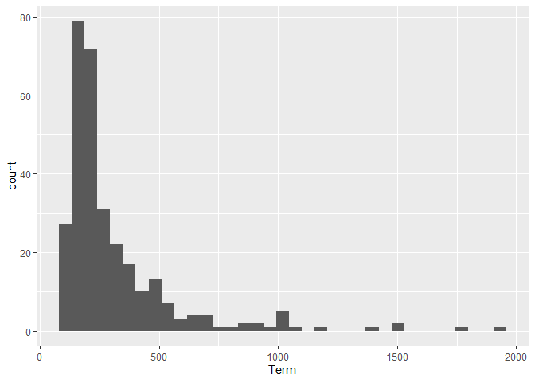

```r
bw_fd <- 2 * IQR(ft_df$count) / (dim(ft_df)[[1]]) ^ (1/3)
ggplot(ft_df, aes(x = count)) + geom_histogram(binwidth = bw_fd) + xlab("Term")
```

Finally, a wordcloud of the stemmed terms appearing at least 250 times:

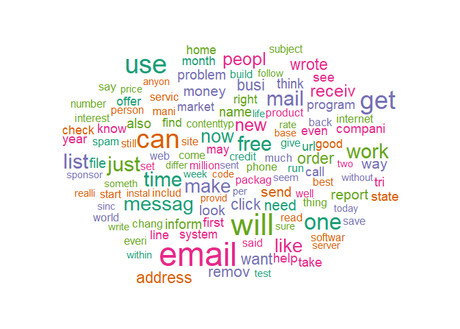

```r
wordcloud(ft_df$term,ft_df$count, scale = c(3, 0.6), min.freq = 250L,
          colors = brewer.pal(5, "Dark2"), random.color = TRUE,
          random.order = TRUE, rot.per = 0, fixed.asp = FALSE)
```

### Building the Training Set

```r
# sample is to randomize the observations
clean_train <- sample(CleanCorpus(raw_train))
clean_train_type <- unlist(meta(clean_train, tag = "class"))
attributes(clean_train_type) <- NULL
dtm_train <- DocumentTermMatrix(clean_train,
                                control = list(dictionary = freq_terms))
dtm_train
```

```
## <<DocumentTermMatrix (documents: 1943, terms: 308)>>
## Non-/sparse entries: 42190/556254
## Sparsity           : 93%
## Maximal term length: 20
## Weighting          : term frequency (tf)
```

Compare the above with the sparsity of the cleaned training corpus without the limiting dictionary:

```r
dtm_train_S <- DocumentTermMatrix(clean_train)
dtm_train_S
```

```
## <<DocumentTermMatrix (documents: 1943, terms: 19211)>>
## Non-/sparse entries: 114275/37212698
## Sparsity           : 100%
## Maximal term length: 441
## Weighting          : term frequency (tf)
```

### Building the Validation Set

```r
clean_val <- sample(CleanCorpus(raw_val))
clean_val_type <- unlist(meta(clean_val, tag = "class"))
attributes(clean_val_type) <- NULL
dtm_val <- DocumentTermMatrix(clean_val,
                              control = list(dictionary = freq_terms))
```

### Building the Testing Set

```r
clean_test <- sample(CleanCorpus(raw_test))
clean_test_type <- unlist(meta(clean_test, tag = "class"))
attributes(clean_test_type) <- NULL
dtm_test <- DocumentTermMatrix(clean_test,
                              control = list(dictionary = freq_terms))
```

### Last step

The `caret` package requires its input to be a numeric matrix. As the DTM is a special form of sparse matrix, we need to convert it to something `caret` understands. The response vector must be a factor for classification, which is why all three `clean_x_type` vectors were created as factors.

```r
train_m <- as.matrix(dtm_train)
clean_train_type <- factor(clean_train_type, levels = c("spam", "ham"))
val_m <- as.matrix(dtm_val)
clean_val_type <- factor(clean_val_type, levels = c("spam", "ham"))
test_m <- as.matrix(dtm_test)
clean_test_type <- factor(clean_test_type, levels = c("spam", "ham"))
```

## Train Models

### Overview

Now we can train the models. The process will generally follow the following path:

1. Select a model family (logistic regression, random forest, etc.)
2. Use the `caret` package on the training set to pick “best” model given the supplied control, pre-processing, or other [hyper-]parameters. This may include some level of validation
3. Switch the hyper-parameters, train again, and compare using validation set
4. Select “best” model from family
5. Repeat with other families
6. Compare performance of final selections using testing/holdout set
7. Take a well-deserved vacation

As the `caret` package serves as an umbrella for over 230 model types living in different packages, we may select a less-sophisticated version of a family if it reduces code complexity and migraine propensity. Forgive us as well if we don’t explain every family and every selection. Below we create the model matrices which will be passed to `caret`.

Experimentation was done with many of the tuning parameters. However, most increases in accuracy came at an inordinate expense of time. Therefore, for the purposes of this exercise, many of the more advantageous options will be limited. For example, cross-validation will be limited to single-pass ten-fold. In production, one should be more vigorous, of course.

### Optimization Metric

Usually, AUC, a function of ROC, is used for classification problems. However, for imbalanced data sets it is suggested to use one of precision, recall, or F1 instead. See [here](https://towardsdatascience.com/accuracy-precision-recall-or-f1-331fb37c5cb9), [here](https://towardsdatascience.com/beyond-accuracy-precision-and-recall-3da06bea9f6c), or [here](https://acutecaretesting.org/en/articles/precision-recall-curves-what-are-they-and-how-are-they-used) for examples.

In our case, the data set is imbalanced, and the cost of a false positive (classifying ham as spam) is greater than a false negative. Originally, we selected precision as the metric, as hitting the “junk” button for something in your inbox is less annoying than having your boss’s email sit in your junk folder.

However, as we trained models, we found some fascinating results. In one of the random forest models, the algorithm found a better model with one less false positive, at the expense of 61 more false negatives. Therefore, we decided to redo the tests using the balanced F1 as the optimization metric.

### Logistic Regression

This is the classic good-old logistic regression in R. There are no hyper/tuning parameters, so the only comparison can be between the method of cross-validation.

```r
# 10-fold CV
tr_ctrl <- trainControl(method = "cv", number = 10L, classProbs = TRUE,
                        summaryFunction = prSummary)
LogR1 <- train(x = train_m, y = clean_train_type, method = "glm",
              family = "binomial", trControl = tr_ctrl, metric = "F", model=TRUE)
LogR1
```

```
## Generalized Linear Model
##
## 1943 samples
##  308 predictor
##    2 classes: 'spam', 'ham'
##
## No pre-processing
## Resampling: Cross-Validated (10 fold)
## Summary of sample sizes: 1749, 1748, 1749, 1749, 1749, 1748, ...
## Resampling results:
##
##   AUC         Precision  Recall     F
##   0.06516546  0.8580168  0.9107246  0.883002
```

```r
LogR1v <- predict(LogR1, val_m)
confusionMatrix(LogR1v, clean_val_type, mode = "prec_recall", positive = "spam")
```

```
## Confusion Matrix and Statistics
##
##           Reference
## Prediction spam ham
##       spam  320  42
##       ham    32 553
##
##                Accuracy : 0.9219
##                  95% CI : (0.9029, 0.9381)
##     No Information Rate : 0.6283
##     P-Value [Acc > NIR] : <2e-16
##
##                   Kappa : 0.8337
##
##  Mcnemar's Test P-Value : 0.2955
##
##               Precision : 0.8840
##                  Recall : 0.9091
##                      F1 : 0.8964
##              Prevalence : 0.3717
##          Detection Rate : 0.3379
##    Detection Prevalence : 0.3823
##       Balanced Accuracy : 0.9193
##
##        'Positive' Class : spam
##
```

```r
# Monte-Carlo Cross validation using 75/25 and 5 iterations
tr_ctrl <- trainControl(method = "LGOCV", number = 10L, p = 0.75,
                        classProbs = TRUE, summaryFunction = prSummary)
LogR2 <- train(x = train_m, y = clean_train_type, method = "glm",
              family = "binomial", trControl = tr_ctrl, metric = "F", model=TRUE)
LogR2
```

```
## Generalized Linear Model
##
## 1943 samples
##  308 predictor
##    2 classes: 'spam', 'ham'
##
## No pre-processing
## Resampling: Repeated Train/Test Splits Estimated (10 reps, 75%)
## Summary of sample sizes: 1458, 1458, 1458, 1458, 1458, 1458, ...
## Resampling results:
##
##   AUC         Precision  Recall     F
##   0.07648102  0.8440346  0.8890173  0.8647148
```

```r
LogR2v <- predict(LogR2, val_m)
confusionMatrix(LogR2v, clean_val_type, mode = "prec_recall", positive = "spam")
```

```
## Confusion Matrix and Statistics
##
##           Reference
## Prediction spam ham
##       spam  320  42
##       ham    32 553
##
##                Accuracy : 0.9219
##                  95% CI : (0.9029, 0.9381)
##     No Information Rate : 0.6283
##     P-Value [Acc > NIR] : <2e-16
##
##                   Kappa : 0.8337
##
##  Mcnemar's Test P-Value : 0.2955
##
##               Precision : 0.8840
##                  Recall : 0.9091
##                      F1 : 0.8964
##              Prevalence : 0.3717
##          Detection Rate : 0.3379
##    Detection Prevalence : 0.3823
##       Balanced Accuracy : 0.9193
##
##        'Positive' Class : spam
##
```

Both versions performed the same on the validation set. As the first has a slightly better F-score, we will select that one.

#### Feature importance

Which terms had the most influence on ham/spam classification using Logistic Regression?

```r
# estimate variable importance
importance <- varImp(LogR2)
# summarize importance
print(importance)
```

```
## glm variable importance
##
##   only 20 most important variables shown (out of 308)
##
##                      Overall
## post                  100.00
## url                    97.92
## click                  97.70
## wrote                  90.27
## want                   74.61
## futur                  65.49
## server                 65.43
## seem                   62.07
## credit                 59.33
## visit                  58.91
## contenttransferencod   58.85
## write                  58.49
## two                    57.40
## use                    56.40
## error                  54.31
## dollar                 48.78
## type                   47.91
## peopl                  47.76
## test                   47.69
## linux                  47.47
```

### Random Forest

The `ranger` package is used as the random forest engine due to its being optimized for higher dimensions.

```r
tr_ctrl <- trainControl(method = "cv", number = 10L, classProbs = TRUE,
                        summaryFunction = prSummary)
RF1 <- train(x = train_m, y = clean_train_type, method = 'ranger', importance = 'impurity',
             trControl = tr_ctrl, metric = "F", tuneLength = 5L)
RF1
```

```
## Random Forest
##
## 1943 samples
##  308 predictor
##    2 classes: 'spam', 'ham'
##
## No pre-processing
## Resampling: Cross-Validated (10 fold)
## Summary of sample sizes: 1750, 1748, 1749, 1748, 1748, 1748, ...
## Resampling results across tuning parameters:
##
##   mtry  splitrule   AUC        Precision  Recall     F
##     2   gini        0.9598693  0.9802080  0.8417598  0.9050521
##     2   extratrees  0.9589222  0.9828103  0.8072878  0.8853248
##    78   gini        0.9076124  0.9150241  0.9194410  0.9162988
##    78   extratrees  0.9395113  0.9243902  0.9338509  0.9281870
##   155   gini        0.8245228  0.9014651  0.9223188  0.9109659
##   155   extratrees  0.8950962  0.9073504  0.9324224  0.9189829
##   231   gini        0.7535807  0.8922116  0.9180538  0.9042518
##   231   extratrees  0.8760631  0.8886891  0.9338923  0.9101560
##   308   gini        0.6631668  0.8874890  0.9223188  0.9040437
##   308   extratrees  0.8388397  0.8912690  0.9338716  0.9114358
##
## Tuning parameter 'min.node.size' was held constant at a value of 1
## F was used to select the optimal model using the largest value.
## The final values used for the model were mtry = 78, splitrule =
##  extratrees and min.node.size = 1.
```

```r
RF1v <- predict(RF1, newdata=val_m)
confusionMatrix(RF1v, clean_val_type, mode = "prec_recall", positive = "spam")
```

```
## Confusion Matrix and Statistics
##
##           Reference
## Prediction spam ham
##       spam  325  18
##       ham    27 577
##
##                Accuracy : 0.9525
##                  95% CI : (0.9369, 0.9651)
##     No Information Rate : 0.6283
##     P-Value [Acc > NIR] : <2e-16
##
##                   Kappa : 0.8977
##
##  Mcnemar's Test P-Value : 0.233
##
##               Precision : 0.9475
##                  Recall : 0.9233
##                      F1 : 0.9353
##              Prevalence : 0.3717
##          Detection Rate : 0.3432
##    Detection Prevalence : 0.3622
##       Balanced Accuracy : 0.9465
##
##        'Positive' Class : spam
##
```

Let’s do a bit wider search among tuning parameters.

```r
rf_grid <- expand.grid(mtry = seq(8, 48, 4),
                       splitrule = c('gini', 'extratrees'),
                       min.node.size = c(1L, 10L))
RF2 <- train(x = train_m, y = clean_train_type, method = 'ranger', importance = 'impurity',
             trControl = tr_ctrl, metric = "F", tuneGrid = rf_grid)
RF2
```

```
## Random Forest
##
## 1943 samples
##  308 predictor
##    2 classes: 'spam', 'ham'
##
## No pre-processing
## Resampling: Cross-Validated (10 fold)
## Summary of sample sizes: 1748, 1748, 1749, 1748, 1749, 1749, ...
## Resampling results across tuning parameters:
##
##   mtry  splitrule   min.node.size  AUC        Precision  Recall
##    8    gini         1             0.9705911  0.9633420  0.9152381
##    8    gini        10             0.9683954  0.9659951  0.9195445
##    8    extratrees   1             0.9711358  0.9719806  0.9238302
##    8    extratrees  10             0.9699666  0.9733659  0.9195445
##   12    gini         1             0.9709628  0.9494133  0.9267288
##   12    gini        10             0.9681634  0.9520939  0.9224224
##   12    extratrees   1             0.9698586  0.9665863  0.9353002
##   12    extratrees  10             0.9689399  0.9621027  0.9324224
##   16    gini         1             0.9692627  0.9464625  0.9252795
##   16    gini        10             0.9688930  0.9452474  0.9209731
##   16    extratrees   1             0.9697263  0.9580291  0.9353209
##   16    extratrees  10             0.9685598  0.9634972  0.9309731
##   20    gini         1             0.9689225  0.9411957  0.9281573
##   20    gini        10             0.9668867  0.9393335  0.9209524
##   20    extratrees   1             0.9678762  0.9540518  0.9381781
##   20    extratrees  10             0.9708979  0.9607867  0.9352795
##   24    gini         1             0.9687893  0.9386130  0.9252795
##   24    gini        10             0.9694745  0.9370235  0.9223810
##   24    extratrees   1             0.9695748  0.9551435  0.9367288
##   24    extratrees  10             0.9687834  0.9580662  0.9338302
##   28    gini         1             0.9693475  0.9363096  0.9281159
##   28    gini        10             0.9663106  0.9313166  0.9238095
##   28    extratrees   1             0.9699114  0.9555167  0.9410352
##   28    extratrees  10             0.9688853  0.9534194  0.9309731
##   32    gini         1             0.9617796  0.9289073  0.9295859
##   32    gini        10             0.9670533  0.9298420  0.9209317
##   32    extratrees   1             0.9678589  0.9510896  0.9381781
##   32    extratrees  10             0.9681864  0.9532061  0.9295238
```

[output cut: 50 more lines]

```
##   0.9236287
##   0.9377670
##   0.9377047
##   0.9228945
##   0.9250193
##   0.9378640
##   0.9327154
##   0.9222807
##   0.9223418
##   0.9344874
##   0.9355756
##
## F was used to select the optimal model using the largest value.
## The final values used for the model were mtry = 12, splitrule =
##  extratrees and min.node.size = 1.
```

```r
RF2v <- predict(RF2, val_m)
confusionMatrix(RF2v, clean_val_type, mode = "prec_recall", positive = "spam")
```

```
## Confusion Matrix and Statistics
##
##           Reference
## Prediction spam ham
##       spam  325  10
##       ham    27 585
##
##                Accuracy : 0.9609
##                  95% CI : (0.9465, 0.9723)
##     No Information Rate : 0.6283
##     P-Value [Acc > NIR] : < 2.2e-16
##
##                   Kappa : 0.9155
##
##  Mcnemar's Test P-Value : 0.008529
##
##               Precision : 0.9701
##                  Recall : 0.9233
##                      F1 : 0.9461
##              Prevalence : 0.3717
##          Detection Rate : 0.3432
##    Detection Prevalence : 0.3537
##       Balanced Accuracy : 0.9532
##
##        'Positive' Class : spam
##
```

#### Feature importance

Which terms had the most influence on ham/spam classification using Random Forest?

```r
# estimate variable importance
importance <- varImp(RF2)
# summarize importance
print(importance)
```

```
## ranger variable importance
##
##   only 20 most important variables shown (out of 308)
##
##                      Overall
## click                100.000
## url                   61.274
## wrote                 38.717
## remov                 37.468
## visit                 23.094
## free                  21.810
## receiv                20.975
## contenttransferencod  19.164
## credit                17.997
## guarante              16.511
## email                 16.419
## inform                12.955
## unsubscrib            12.006
## contact               11.496
## use                   11.304
## repli                 11.269
## offer                 10.977
## contenttyp            10.912
## life                   9.995
## onlin                  9.792
```

### Naive Bayes

```r
tr_ctrl <- trainControl(method = "cv", number = 10L, classProbs = TRUE,
                        summaryFunction = prSummary)
NB1 <- train(x = train_m, y = clean_train_type, method = "nb",
             trControl = tr_ctrl, metric = "F")
NB1
```

```
## Naive Bayes
##
## 1943 samples
##  308 predictor
##    2 classes: 'spam', 'ham'
##
## No pre-processing
## Resampling: Cross-Validated (10 fold)
## Summary of sample sizes: 1750, 1749, 1748, 1750, 1748, 1749, ...
## Resampling results across tuning parameters:
##
##   usekernel  AUC        Precision  Recall      F
##   FALSE            NaN  NaN               NaN         NaN
##    TRUE      0.8645713    1        0.03610766  0.06863714
##
## Tuning parameter 'fL' was held constant at a value of 0
## Tuning
##  parameter 'adjust' was held constant at a value of 1
## F was used to select the optimal model using the largest value.
## The final values used for the model were fL = 0, usekernel = TRUE
##  and adjust = 1.
```

```r
NB1v <- predict(NB1, val_m)
confusionMatrix(NB1v, clean_val_type, mode = "prec_recall", positive = "spam")
```

```
## Confusion Matrix and Statistics
##
##           Reference
## Prediction spam ham
##       spam   13   2
##       ham   339 593
##
##                Accuracy : 0.6399
##                  95% CI : (0.6084, 0.6705)
##     No Information Rate : 0.6283
##     P-Value [Acc > NIR] : 0.2405
##
##                   Kappa : 0.0417
##
##  Mcnemar's Test P-Value : <2e-16
##
##               Precision : 0.86667
##                  Recall : 0.03693
##                      F1 : 0.07084
##              Prevalence : 0.37170
##          Detection Rate : 0.01373
##    Detection Prevalence : 0.01584
##       Balanced Accuracy : 0.51679
##
##        'Positive' Class : spam
##
```

This is an *awfully* performing model. Naive Bayes is known to be very sensitive to class imbalances. Let’s implement up-sampling and a wider search.

```r
tr_ctrl <- trainControl(method = "cv", number = 10L, classProbs = TRUE,
                        summaryFunction = prSummary, sampling = 'up')
nb_grid <- expand.grid(usekernel = TRUE,
                       fL = seq(0.25, 0.75, 0.05),
                       adjust = 1)
NB2 <- train(x = train_m, y = clean_train_type, method = "nb",
             trControl = tr_ctrl, metric = "F", tuneGrid = nb_grid)
NB2
```

```
## Naive Bayes
##
## 1943 samples
##  308 predictor
##    2 classes: 'spam', 'ham'
##
## No pre-processing
## Resampling: Cross-Validated (10 fold)
## Summary of sample sizes: 1749, 1749, 1749, 1749, 1749, 1749, ...
## Addtional sampling using up-sampling
##
## Resampling results across tuning parameters:
##
##   fL    AUC        Precision  Recall      F
##   0.25  0.8417755  0.9088889  0.08900621  0.1597567
##   0.30  0.8345597  0.8491176  0.10627329  0.1795763
##   0.35  0.8229549  0.8546093  0.11211180  0.1845699
##   0.40  0.8362909  0.8916667  0.10494824  0.1793880
##   0.45  0.8338190  0.9133333  0.10354037  0.1826036
##   0.50  0.8302064  0.8875000  0.10068323  0.1741349
##   0.55  0.8301797  0.9196032  0.10339545  0.1750240
##   0.60  0.8222250  0.8914286  0.10194617  0.1760769
##   0.65  0.8371354  0.9168831  0.10927536  0.1859311
##   0.70  0.8364672  0.9524510  0.10486542  0.1809627
##   0.75  0.8335795  0.9051535  0.09774327  0.1680177
##
## Tuning parameter 'usekernel' was held constant at a value of TRUE
##
## Tuning parameter 'adjust' was held constant at a value of 1
## F was used to select the optimal model using the largest value.
## The final values used for the model were fL = 0.65, usekernel = TRUE
##  and adjust = 1.
```

```r
NB2v <- predict(NB2, val_m)
confusionMatrix(NB2v, clean_val_type, mode = "prec_recall", positive = "spam")
```

```
## Confusion Matrix and Statistics
##
##           Reference
## Prediction spam ham
##       spam   36   2
##       ham   316 593
##
##                Accuracy : 0.6642
##                  95% CI : (0.6331, 0.6943)
##     No Information Rate : 0.6283
##     P-Value [Acc > NIR] : 0.01174
##
##                   Kappa : 0.1209
##
##  Mcnemar's Test P-Value : < 2e-16
##
##               Precision : 0.94737
##                  Recall : 0.10227
##                      F1 : 0.18462
##              Prevalence : 0.37170
##          Detection Rate : 0.03801
##    Detection Prevalence : 0.04013
##       Balanced Accuracy : 0.54946
##
##        'Positive' Class : spam
##
```

Results are still **miserable**. Naive Bayes also assumes **Independence** between all features - with engligh text, words/terms are likely to have correlations thus violating the core assumption of Naive Bayes. Since our current terms also some leakage of HTML tags and attributes, there are going to be correlations between terms we have selected. Naive Bayes would probably perform significantly better if we stipped all HTML terms and made a pass on reducing features by looking for correlations.

#### Feature importance

Which terms had the most influence on ham/spam classification using Naive Bayes?

```r
# estimate variable importance
importance <- varImp(NB2)
# summarize importance
print(importance)
```

```
## ROC curve variable importance
##
##   only 20 most important variables shown (out of 308)
##
##                      Importance
## click                    100.00
## email                     91.87
## remov                     72.56
## wrote                     72.45
## receiv                    68.95
## free                      61.85
## will                      59.82
## url                       54.24
## inform                    51.45
## busi                      43.61
## address                   42.60
## offer                     42.37
## repli                     35.31
## money                     35.17
## now                       32.42
## contenttransferencod      32.36
## can                       32.21
## month                     31.56
## send                      30.95
## contenttyp                30.15
```

### Neural Network

```r
tr_ctrl <- trainControl(method = "cv", number = 10L, classProbs = TRUE,
                        summaryFunction = prSummary)

NN1 <- train(x = train_m, y = clean_train_type, method = "nnet", trace = FALSE,
             trControl = tr_ctrl, metric = "F", tuneLength=5L, maxit = 250L)
NN1
```

```
## Neural Network
##
## 1943 samples
##  308 predictor
##    2 classes: 'spam', 'ham'
##
## No pre-processing
## Resampling: Cross-Validated (10 fold)
## Summary of sample sizes: 1749, 1748, 1750, 1749, 1749, 1749, ...
## Resampling results across tuning parameters:
##
##   size  decay  AUC        Precision  Recall     F
##   1     0e+00  0.1938775  0.9151743  0.9108489  0.9124544
##   1     1e-04  0.3399736  0.9214103  0.9195238  0.9196794
##   1     1e-03  0.4819758  0.9196001  0.9136853  0.9156806
```

[output cut: 25 more lines]

```r
NN1v <- predict(NN1, val_m)
confusionMatrix(NN1v, clean_val_type, mode = "prec_recall", positive = "spam")
```

```
## Confusion Matrix and Statistics
##
##           Reference
## Prediction spam ham
##       spam  314  20
##       ham    38 575
##
##                Accuracy : 0.9388
##                  95% CI : (0.9215, 0.9532)
##     No Information Rate : 0.6283
##     P-Value [Acc > NIR] : <2e-16
##
##                   Kappa : 0.8675
##
##  Mcnemar's Test P-Value : 0.0256
##
##               Precision : 0.9401
##                  Recall : 0.8920
##                      F1 : 0.9155
##              Prevalence : 0.3717
##          Detection Rate : 0.3316
##    Detection Prevalence : 0.3527
##       Balanced Accuracy : 0.9292
##
##        'Positive' Class : spam
##
```

Some light tuning:

```r
nn_grid <- expand.grid(size = 1L, decay = c(0.99, seq(0.95, 0.05, -0.05), 0.01))
NN2 <- train(x = train_m, y = clean_train_type, method = "nnet", trace = FALSE,
             trControl = tr_ctrl, metric = "F", tuneGrid = nn_grid,
             maxit = 250L)
NN2
```

```
## Neural Network
##
## 1943 samples
##  308 predictor
##    2 classes: 'spam', 'ham'
##
## No pre-processing
## Resampling: Cross-Validated (10 fold)
## Summary of sample sizes: 1749, 1748, 1748, 1748, 1750, 1749, ...
## Resampling results across tuning parameters:
##
##   decay  AUC        Precision  Recall     F
##   0.01   0.6383898  0.9212195  0.9121946  0.9162207
##   0.05   0.7692994  0.9240296  0.9265839  0.9247392
##   0.10   0.8072211  0.9355148  0.9208489  0.9274281
##   0.15   0.8402565  0.9353433  0.9208282  0.9274672
##   0.20   0.8527932  0.9347728  0.9293996  0.9313668
##   0.25   0.8140667  0.9313337  0.9308282  0.9303504
##   0.30   0.8663416  0.9369526  0.9208075  0.9279617
##   0.35   0.8758571  0.9408470  0.9308282  0.9349326
##   0.40   0.8753815  0.9421074  0.9294203  0.9349393
##   0.45   0.8786946  0.9405514  0.9294410  0.9341948
##   0.50   0.8834925  0.9433573  0.9308075  0.9362327
##   0.55   0.8856740  0.9518686  0.9265010  0.9380507
##   0.60   0.8848396  0.9489563  0.9279503  0.9374756
##   0.65   0.8895250  0.9503670  0.9322567  0.9404662
##   0.70   0.8917974  0.9462910  0.9293996  0.9369784
##   0.75   0.8945690  0.9476758  0.9279503  0.9367894
##   0.80   0.9030283  0.9518262  0.9250932  0.9372766
##   0.85   0.9035252  0.9531726  0.9294203  0.9402971
##   0.90   0.9059117  0.9528485  0.9265217  0.9386527
##   0.95   0.9077766  0.9539975  0.9279503  0.9400688
##   0.99   0.9121959  0.9570959  0.9250725  0.9398958
##
## Tuning parameter 'size' was held constant at a value of 1
## F was used to select the optimal model using the largest value.
## The final values used for the model were size = 1 and decay = 0.65.
```

```r
NN2v <- predict(NN2, val_m)
confusionMatrix(NN2v, clean_val_type, mode = "prec_recall", positive = "spam")
```

```
## Confusion Matrix and Statistics
##
##           Reference
## Prediction spam ham
##       spam  320  15
##       ham    32 580
##
##                Accuracy : 0.9504
##                  95% CI : (0.9345, 0.9633)
##     No Information Rate : 0.6283
##     P-Value [Acc > NIR] : <2e-16
##
##                   Kappa : 0.8927
##
##  Mcnemar's Test P-Value : 0.0196
##
##               Precision : 0.9552
##                  Recall : 0.9091
##                      F1 : 0.9316
##              Prevalence : 0.3717
##          Detection Rate : 0.3379
##    Detection Prevalence : 0.3537
##       Balanced Accuracy : 0.9419
##
##        'Positive' Class : spam
##
```

#### Feature importance

Which terms had the most influence on ham/spam classification using a Neural Network?

```r
# estimate variable importance
importance <- varImp(NN2)
# summarize importance
print(importance)
```

```
## nnet variable importance
##
##   only 20 most important variables shown (out of 308)
##
##                      Overall
## url                   100.00
## click                  85.11
## wrote                  69.95
## visit                  57.65
## write                  46.26
## guarante               43.72
## use                    43.49
## seem                   40.65
## satalk                 39.19
## old                    39.14
## two                    38.81
## home                   38.03
## futur                  35.39
## dollar                 35.37
## file                   35.15
## credit                 35.08
## contenttyp             33.92
## minut                  33.17
## repli                  33.17
## contenttransferencod   32.85
```

### Gradient Boosted Machines

```r
tr_ctrl <- trainControl(method = "cv", number = 10L, classProbs = TRUE,
                        summaryFunction = prSummary)
GBM1 <- train(x = train_m, y = clean_train_type, method = "gbm", verbose = FALSE,
              trControl = tr_ctrl, tuneLength = 5L, metric = "F")
GBM1v <- predict(GBM1, val_m)
confusionMatrix(GBM1v, clean_val_type, mode = "prec_recall", positive = "spam")
```

```
## Confusion Matrix and Statistics
##
##           Reference
## Prediction spam ham
##       spam  325  11
##       ham    27 584
##
##                Accuracy : 0.9599
##                  95% CI : (0.9453, 0.9715)
##     No Information Rate : 0.6283
##     P-Value [Acc > NIR] : < 2e-16
##
##                   Kappa : 0.9133
##
##  Mcnemar's Test P-Value : 0.01496
##
##               Precision : 0.9673
##                  Recall : 0.9233
##                      F1 : 0.9448
##              Prevalence : 0.3717
##          Detection Rate : 0.3432
##    Detection Prevalence : 0.3548
##       Balanced Accuracy : 0.9524
##
##        'Positive' Class : spam
##
```

This model looks really good. Let’s throw a little extra fine-tuning in. After running a wide-scale grid, the best option is selected below, so that the entire grid doesn’t have to rerun every time.

```r
gbm_grid <- expand.grid(n.trees = 400L,
                     interaction.depth = 7L,
                     shrinkage = 0.1,
                     n.minobsinnode = 10L)
GBM2 <- train(x = train_m, y = clean_train_type, method = "gbm", verbose = FALSE,
              trControl = tr_ctrl, tuneGrid = gbm_grid, metric = "F")
GBM2
```

```
## Stochastic Gradient Boosting
##
## 1943 samples
##  308 predictor
##    2 classes: 'spam', 'ham'
##
## No pre-processing
## Resampling: Cross-Validated (10 fold)
## Summary of sample sizes: 1749, 1750, 1748, 1748, 1749, 1748, ...
## Resampling results:
##
##   AUC        Precision  Recall     F
##   0.9716112  0.9437718  0.9294824  0.936128
##
## Tuning parameter 'n.trees' was held constant at a value of 400
##  7
## Tuning parameter 'shrinkage' was held constant at a value of 0.1
##
## Tuning parameter 'n.minobsinnode' was held constant at a value of 10
```

```r
GBM2v <- predict(GBM2, val_m)
confusionMatrix(GBM2v, clean_val_type, mode = "prec_recall", positive = "spam")
```

```
## Confusion Matrix and Statistics
##
##           Reference
## Prediction spam ham
##       spam  325  12
##       ham    27 583
##
##                Accuracy : 0.9588
##                  95% CI : (0.9441, 0.9706)
##     No Information Rate : 0.6283
##     P-Value [Acc > NIR] : < 2e-16
##
##                   Kappa : 0.9111
##
##  Mcnemar's Test P-Value : 0.02497
##
##               Precision : 0.9644
##                  Recall : 0.9233
##                      F1 : 0.9434
##              Prevalence : 0.3717
##          Detection Rate : 0.3432
##    Detection Prevalence : 0.3559
##       Balanced Accuracy : 0.9516
##
##        'Positive' Class : spam
##
```

#### Feature importance

Which terms had the most influence on ham/spam classification using a Gradient Boosted Machines?

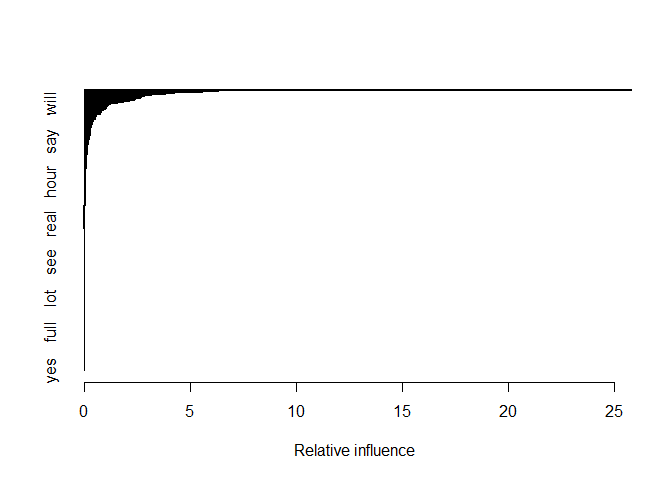

```
##                                       var      rel.inf
## click                               click 2.581944e+01
## wrote                               wrote 6.355481e+00
## contenttransferencod contenttransferencod 5.556169e+00
## url                                   url 4.265440e+00
## email                               email 3.820689e+00
## credit                             credit 3.154606e+00
## inform                             inform 2.838570e+00
## free                                 free 2.681326e+00
## repli                               repli 2.675613e+00
## visit                               visit 2.581664e+00
## use                                   use 2.415561e+00
## receiv                             receiv 2.355206e+00
## tri                                   tri 2.128315e+00
## remov                               remov 1.865354e+00
## will                                 will 1.550087e+00
## satalk                             satalk 1.236813e+00
## dollar                             dollar 1.167111e+00
## said                                 said 1.078139e+00
## spam                                 spam 1.050712e+00
## money                               money 1.047632e+00
## think                               think 1.015805e+00
## guarante                         guarante 1.009096e+00
## life                                 life 9.194919e-01
## onlin                               onlin 8.165683e-01
## file                                 file 8.138042e-01
## write                               write 7.783694e-01
## home                                 home 7.707283e-01
## month                               month 5.625751e-01
## seem                                 seem 5.579588e-01
## internet                         internet 5.535825e-01
## busi                                 busi 5.251096e-01
## origin                             origin 5.096281e-01
## run                                   run 4.878476e-01
## price                               price 4.530023e-01
## base                                 base 4.445244e-01
## offer                               offer 3.944501e-01
## still                               still 3.892529e-01
## opportun                         opportun 3.714325e-01
## old                                   old 3.534826e-01
```

[output cut: 254 more lines]

```
## sign                                 sign 0.000000e+00
## softwar                           softwar 0.000000e+00
## sourc                               sourc 0.000000e+00
## state                               state 0.000000e+00
## support                           support 0.000000e+00
## system                             system 0.000000e+00
## tell                                 tell 0.000000e+00
## textplain                       textplain 0.000000e+00
## though                             though 0.000000e+00
## type                                 type 0.000000e+00
## unsubscrib                     unsubscrib 0.000000e+00
## way                                   way 0.000000e+00
## well                                 well 0.000000e+00
## wish                                 wish 0.000000e+00
## yes                                   yes 0.000000e+00
```

```r
# estimate variable importance
summary(GBM2)
```

### Other models

With over 230 possible models, there are many more options to train, like XGBoost, Neural Networks, Bayesian Regression, Support Vector Machines, etc. We don’t need to exhaust the possibilities here.

## Test Models

```r
LogRt <- predict(LogR1, test_m)
RFt <- predict(RF1, newdata=test_m)
NNt <- predict(NN2, test_m)
NBt <- predict(NB2, test_m) # For laughs
GBMt <- predict(GBM2, test_m)
confusionMatrix(LogRt, clean_test_type, mode = "prec_recall", positive = "spam")
```

```
## Confusion Matrix and Statistics
##
##           Reference
## Prediction spam ham
##       spam  323  54
##       ham    26 603
##
##                Accuracy : 0.9205
##                  95% CI : (0.902, 0.9364)
##     No Information Rate : 0.6531
##     P-Value [Acc > NIR] : < 2.2e-16
##
##                   Kappa : 0.8277
##
##  Mcnemar's Test P-Value : 0.002539
##
##               Precision : 0.8568
##                  Recall : 0.9255
##                      F1 : 0.8898
##              Prevalence : 0.3469
##          Detection Rate : 0.3211
##    Detection Prevalence : 0.3748
##       Balanced Accuracy : 0.9217
##
##        'Positive' Class : spam
##
```

```r
confusionMatrix(RFt, clean_test_type, mode = "prec_recall", positive = "spam")
```

```
## Confusion Matrix and Statistics
##
##           Reference
## Prediction spam ham
##       spam  318  23
##       ham    31 634
##
##                Accuracy : 0.9463
##                  95% CI : (0.9305, 0.9594)
##     No Information Rate : 0.6531
##     P-Value [Acc > NIR] : <2e-16
##
##                   Kappa : 0.8809
##
##  Mcnemar's Test P-Value : 0.3408
##
##               Precision : 0.9326
##                  Recall : 0.9112
##                      F1 : 0.9217
##              Prevalence : 0.3469
##          Detection Rate : 0.3161
##    Detection Prevalence : 0.3390
##       Balanced Accuracy : 0.9381
##
##        'Positive' Class : spam
##
```

```r
confusionMatrix(NNt, clean_test_type, mode = "prec_recall", positive = "spam")
```

```
## Confusion Matrix and Statistics
##
##           Reference
## Prediction spam ham
##       spam  320  18
##       ham    29 639
##
##                Accuracy : 0.9533
##                  95% CI : (0.9384, 0.9655)
##     No Information Rate : 0.6531
##     P-Value [Acc > NIR] : <2e-16
##
##                   Kappa : 0.8961
##
##  Mcnemar's Test P-Value : 0.1447
##
##               Precision : 0.9467
##                  Recall : 0.9169
##                      F1 : 0.9316
##              Prevalence : 0.3469
##          Detection Rate : 0.3181
##    Detection Prevalence : 0.3360
##       Balanced Accuracy : 0.9448
##
##        'Positive' Class : spam
##
```

```r
confusionMatrix(NBt, clean_test_type, mode = "prec_recall", positive = "spam")
```

```
## Confusion Matrix and Statistics
##
##           Reference
## Prediction spam ham
##       spam   50   8
##       ham   299 649
##
##                Accuracy : 0.6948
##                  95% CI : (0.6653, 0.7232)
##     No Information Rate : 0.6531
##     P-Value [Acc > NIR] : 0.002776
##
##                   Kappa : 0.1629
##
##  Mcnemar's Test P-Value : < 2.2e-16
##
##               Precision : 0.86207
##                  Recall : 0.14327
##                      F1 : 0.24570
##              Prevalence : 0.34692
##          Detection Rate : 0.04970
##    Detection Prevalence : 0.05765
##       Balanced Accuracy : 0.56554
##
##        'Positive' Class : spam
##
```

```r
confusionMatrix(GBMt, clean_test_type, mode = "prec_recall", positive = "spam")
```

```
## Confusion Matrix and Statistics
##
##           Reference
## Prediction spam ham
##       spam  316  18
##       ham    33 639
##
##                Accuracy : 0.9493
##                  95% CI : (0.9339, 0.962)
##     No Information Rate : 0.6531
##     P-Value [Acc > NIR] : < 2e-16
##
##                   Kappa : 0.887
##
##  Mcnemar's Test P-Value : 0.04995
##
##               Precision : 0.9461
##                  Recall : 0.9054
##                      F1 : 0.9253
##              Prevalence : 0.3469
##          Detection Rate : 0.3141
##    Detection Prevalence : 0.3320
##       Balanced Accuracy : 0.9390
##
##        'Positive' Class : spam
##
```

# Discussion

With our initial pass on this project, we did NOT remove HTML from email messages and as a consequence, HTML tags and attribute names and values became “words” or “terms” used by our models to help resolve SPAM vs HAM. Interestingly, our models performed significantly better and the HTML terms and attribute ended up being the most important features used as criteria by models. After seeing this, we modified our email cleaning to actively remove HTML markup. Our model perform dropped ~7% across all models without HTML. This suggests that the very presense of HTML markup in the corpus is a feature associated with and predictive of SPAM.

The email corpus is from the early 2000’s at a time when most email clients did NOT use HTML markup by default, so most HAM would *NOT* have included much if any HTML. SPAM on the other hand often included HTML links and images intended to draw the recipient to a website or email address where they could buy something.

While the presense of HTML was an indicator of SPAM in the early 2000’s, we suspect that models trained with HTML would perform poorly today as most email clients routinely use HTML markup for text formating, shared links and images. For this reason, we chose to remove the HTML and try training a model on only the email text, as that might perform better over time.

Note that whlie we tried to remove HTML markup, when we inspect the terms, we still see some words that look suspiciouly like HTML, for example, “contenttype”. This may suggest some leakage of HTML that we missed during scrubbing.

If you inspect the terms, you may note missing trailing characters. This is not a bug, but rather part of the word stem approach to simplifying the word list by finding similar words. For example, “run”, “running”, “runs”, “runner” all have the same base “run”. The SnowballC package drops the endings so all the variants collapse to the same word root.

If we really wanted to expand this project, some additional features we might include beyond the word list:

- Possibly add a boolean feature indicating whether the email contained any URL’s
- Possibly add a boolean feature whether there were any HTML markup in the email
- Use Correlation matrices to identify auto-correlation between words and remove unnecessary terms.

Since email language and markup changes over time, and spammers are constantly changing their email to get past spam filters, any model built to separate HAM vs SPAM will probably need to be constantly retrained.

# Epilogue

```r
stopCluster(cl)
```